# Chapter 3: In Class Answers

## Example 1: Time to Failure

```r
electric_component_failure = data.frame(time = c(127, 124, 121, 118, 125, 123, 136, 131, 131, 120, 140, 125, 124, 119, 137, 133, 129, 128, 125, 141,
121, 133, 124, 125, 142, 137, 128, 140,
151, 124, 129, 131, 160, 142, 130, 129,
125, 123, 122, 126))

mean(electric_component_failure$time)
```

```
## [1] 129.975
```

```r
sd(electric_component_failure$time)
```

```
## [1] 8.914084
```

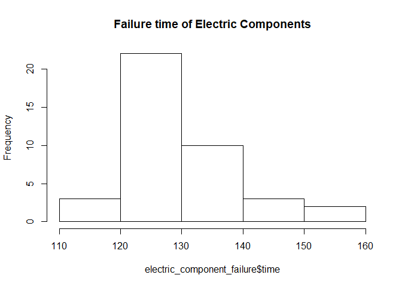

```r
hist(electric_component_failure$time, breaks = 5, main = "Failure time of Electric Components")
```

```r
stem(electric_component_failure$time)
```

```
##
##   The decimal point is 1 digit(s) to the right of the |
##
##   11 | 89
##   12 | 0112334444
##   12 | 555556788999
##   13 | 011133
##   13 | 677
##   14 | 00122
##   14 |
##   15 | 1
##   15 |
##   16 | 0
```

## Example 2: Viscosity

Data on the viscosity of liquid substances is given in the table below. Construct a probability plot of the data. Which distribution fits the data best?

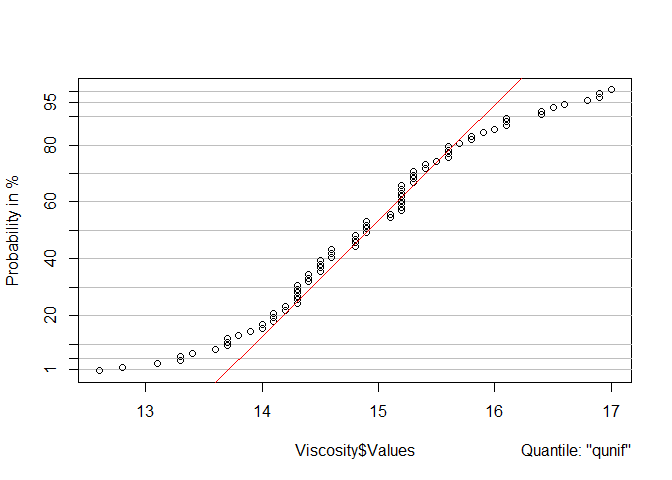

```r
Viscosity = data.frame(Values = c(13.3, 14.9, 15.8, 16.0, 14.5, 13.7, 13.7, 14.9,
15.3, 15.2, 15.1, 13.6, 15.3, 14.5, 13.4, 15.3, 14.3, 15.3, 14.1, 14.3, 14.8, 15.6, 14.8, 15.6, 15.2, 15.8, 14.3, 16.1, 14.5, 13.3, 14.3, 13.9, 14.6, 14.1, 16.4, 15.2,
14.1, 15.4, 16.9, 14.4, 14.3, 15.2, 14.2, 14.0, 16.1, 15.2, 16.9, 14.4, 13.1, 15.9, 14.9, 13.7, 15.5, 16.5, 15.2, 13.8, 12.6, 14.8, 14.4, 15.6, 14.6, 15.1, 15.2, 14.5, 14.3, 17.0, 14.6, 12.8, 15.4, 14.9, 16.4, 16.1, 15.2, 14.8, 14.2, 16.6, 16.8, 14.0, 15.7, 15.6))

library(e1071)
probplot(Viscosity$Values, qdist = "qunif")
```

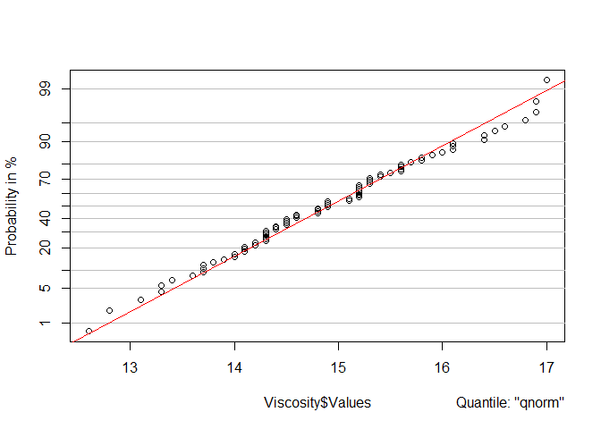

```r
probplot(Viscosity$Values, qdist = "qnorm")
```

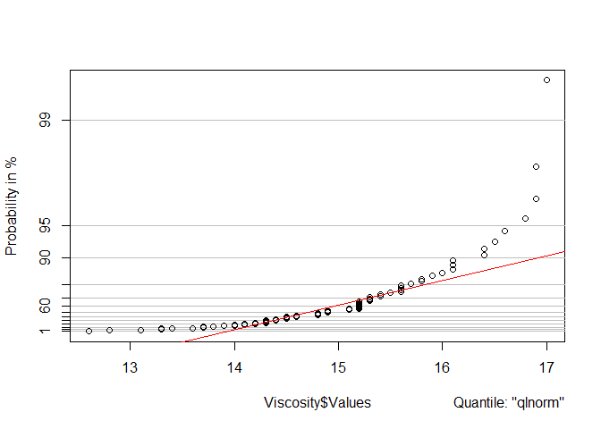

```r
probplot(Viscosity$Values, qdist = "qlnorm")
```

The values appear to follow a normal distribution.

## Example 3: Tensile Strength

The tensile strength of a metal part is normally distributed with mean 600 lb and standard deviation 50 lb. a. If 50,000 parts are produced, how many would you expect to fail to meet a minimum specification limit of 550 lb tensile strength? b. Use the standard normal table at the end of the book to verify question 1. c. What percentage of the parts will fall inbetween the range of 570 and 630? d. Verify the range using the standard normal tables in the back of the book. e. Find the tensile strength limits (upper and lower) that cover 90% of the production.

```r
#a
percentage = pnorm((550-600)/50)
total_failed = 50000 * percentage
print(round(total_failed))
```

```
## [1] 7933
```

```r
#c
prob_one = pnorm((630-600)/50)
prob_two = pnorm((570-600)/50)
prob_one - prob_two
```

```
## [1] 0.4514938
```

```r
#e

print(paste("90% of the products will be inbetween", round(qnorm(.05, mean = 600, sd = 50)), "and", round(qnorm(.95, mean=600, sd=50)
) ))
```

```
## [1] "90% of the products will be inbetween 518 and 682"
```

## Example 4: Mechatronic Assembly

A mechatronic assembly is subjected to a final functional test. Suppose that defects occur at random in these assemblies, and that defects occur according to a Poisson distribution with parameter lambda = 0.02.  
a What is the probability that an assembly will have exactly one defect? b What is the probability that an assembly will have one or more defects?

```r
#a
ppois(1, lambda = .02) - ppois(0, lambda = .02)
```

```
## [1] 0.01960397
```

```r
#b
ppois(0, lambda = .02, lower = F)
```

```
## [1] 0.01980133
```

## Example 5: Defective Furnaces

```r
dbinom(5, 100, .05)
```

```
## [1] 0.1800178
```